# R Notebook

### Objeto de tipo modelo

```r
mdl_weight_vs_length
```

```
Call:
lm(formula = weight ~ length, data = bream)

Coefficients:
(Intercept)       length
   -1035.35        54.55
```

Solamente utilizando la variable que contiene nuestro modelo mdl_weight_vs_length, no podemos acceder al valor del intercepto ni al de la pendiete. Para acceder a ellos utilizamos diferentes funciones en R.

La función *coefficients* nos devuelve un vector con los valores del intercepto y la pendiente:

```r
coefficients(mdl_weight_vs_length)
```

```
(Intercept)      length
-1035.34757    54.54998
```

La función *fitted* nos devuelve un vector con el valor de las predicciones del dataset original. Nos da todos los valores de la linea azul.

```r
fitted(mdl_weight_vs_length)
```

[output not shown]

```r
predict(mdl_weight_vs_length,explanatory_data)
```

```
         1          2          3          4          5          6          7          8          9         10
  55.65205  110.20203  164.75202  219.30200  273.85198  328.40196  382.95194  437.50192  492.05190  546.60188
        11         12         13         14         15         16         17         18         19         20
 601.15186  655.70184  710.25182  764.80181  819.35179  873.90177  928.45175  983.00173 1037.55171 1092.10169
        21
1146.65167
```

```r
residuals(mdl_weight_vs_length)
```

```
          1           2           3           4           5           6           7           8           9
  11.788007   16.148023   71.603021  -36.316934   19.773070   23.408076   73.408076  -80.231909  -20.231909
         10          11          12          13          14          15          16          17          18
 -19.326892  -38.871893  -30.236888  -52.056880 -233.876873   31.578126   31.578126   77.028145   77.028145
         19          20          21          22          23          24          25          26          27
 -40.246846   -5.701844  -97.066838    7.478164  -62.976834  -19.341829   -4.796827   25.658171    9.748175
         28          29          30          31          32          33          34          35
 -34.436811   96.108190  207.923204   46.098232   81.098232  -14.361745  -29.821722  -87.551710
```

```r
bream$weight - fitted(mdl_weight_vs_length)
```

```
          1           2           3           4           5           6           7           8           9
  11.788007   16.148023   71.603021  -36.316934   19.773070   23.408076   73.408076  -80.231909  -20.231909
         10          11          12          13          14          15          16          17          18
 -19.326892  -38.871893  -30.236888  -52.056880 -233.876873   31.578126   31.578126   77.028145   77.028145
         19          20          21          22          23          24          25          26          27
 -40.246846   -5.701844  -97.066838    7.478164  -62.976834  -19.341829   -4.796827   25.658171    9.748175
         28          29          30          31          32          33          34          35
 -34.436811   96.108190  207.923204   46.098232   81.098232  -14.361745  -29.821722  -87.551710
```

```r
mdl_weight_vs_length$df.residual #grados de libertad
```

```
[1] 33
```

```r
summary(mdl_weight_vs_length)
```

```
Call:
lm(formula = weight ~ length, data = bream)

Residuals:
     Min       1Q   Median       3Q      Max
-233.877  -35.377   -4.797   31.578  207.923

Coefficients:
             Estimate Std. Error t value Pr(>|t|)
(Intercept) -1035.348    107.973  -9.589 4.58e-11 ***
length         54.550      3.539  15.415  < 2e-16 ***
---
Signif. codes:  0 ‘***’ 0.001 ‘**’ 0.01 ‘*’ 0.05 ‘.’ 0.1 ‘ ’ 1

Residual standard error: 74.15 on 33 degrees of freedom
Multiple R-squared:  0.8781,    Adjusted R-squared:  0.8744
F-statistic: 237.6 on 1 and 33 DF,  p-value: < 2.2e-16
```

```r
library(broom)
```

[output not shown]

[output not shown]

[output cut: 25 more lines]

[output not shown]

### Transformar variables

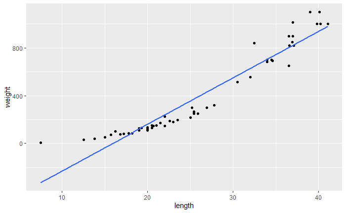

```r
ggplot(perch, aes(length, weight))+
  geom_point()+
  geom_smooth(method = "lm", se = FALSE)
```

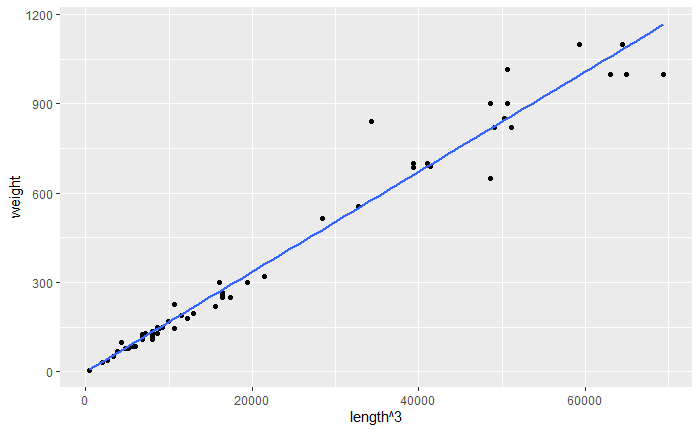

```r
ggplot(perch, aes(length^3, weight))+
  geom_point()+
  geom_smooth(method = "lm", se = FALSE)
```

| length |
| --- |
| 10 |
| 15 |
| 20 |
| 25 |
| 30 |
| 35 |
| 40 |

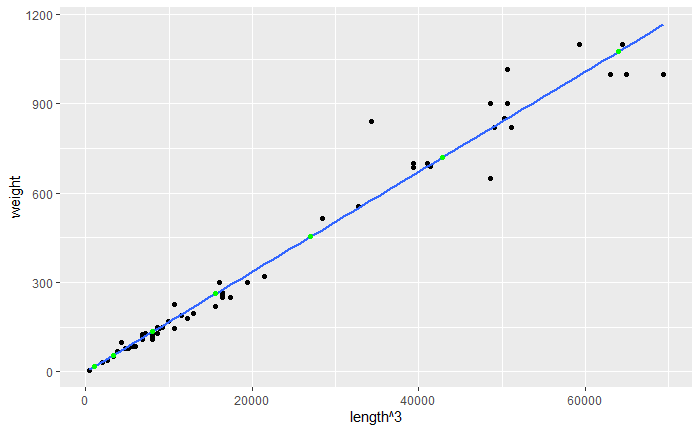

```r
ggplot(perch, aes(length^3, weight))+
  geom_point()+
  geom_smooth(method = "lm", se = FALSE) +
  geom_point(data = predicted_data, color = "green")
```

```r
ggplot(perch, aes(length, weight))+
  geom_point()+
  geom_smooth(method = "lm", se = FALSE) +
  geom_point(data = predicted_data, color = "green")
```

[output not shown]

```r
grafica = perch %>%
  mutate(cubo = length ^3  )
```

### Interpretar las metricas del modelo para evaluarlo

#### r cuadrado (proporcion de la variancia en la variable dependiente que se explica con la variable independiente 0 - 1)

```r
summary(mdl_weight_vs_length)
```

```r
mdl_weight_vs_length %>%
  glance() %>%
  pull(r.squared)
```

[output not shown]

### RSE (Residual Standard Error)

la diferencia “tipica” entre la prediccion y el valor observado. Tiene la misma dimension que la variable dependiente.

```r
summary(mdl_weight_vs_length)
```

```r
mdl_weight_vs_length %>%
  glance() %>%
  pull(sigma)
```

[output not shown]

#### calculo manual

```r
bream %>%
  mutate(
    residuals_sq = residuals(mdl_weight_vs_length) ^2  ) %>%
  summarise(
    resid_sum_of_sq = sum(residuals_sq),
    deg_freedom = n() - 2,
    rse = sqrt(resid_sum_of_sq/deg_freedom)
  )
```

[output not shown]

### RMSE (Root mean square error)

```r
bream %>%
  mutate(
    residuals_sq = residuals(mdl_weight_vs_length) ^2  ) %>%
  summarise(
    resid_sum_of_sq = sum(residuals_sq),
    deg_freedom = n(),
    rse = sqrt(resid_sum_of_sq/deg_freedom)
  )
```

[output not shown]

## Evaluar modelos de forma grafica

```r
# install.packages("ggfortify")
library(ggfortify)
```

## Residual vs fitted

```r
autoplot(mdl_weight_vs_length,which = 1)
```

[output not shown]

```r
mdl_perch_bad <- lm(formula = weight ~ length, data = perch)
autoplot(mdl_perch_bad,which = 1)
```

[output not shown]

### QQ plot

```r
autoplot(mdl_weight_vs_length,which = 2)
```

[output not shown]

```r
autoplot(mdl_perch_bad,which = 2)
```

[output not shown]

### scale location

```r
autoplot(mdl_weight_vs_length,which = 3)
```

[output not shown]

```r
autoplot(mdl_perch_bad,which = 3)
```

[output not shown]

```r
autoplot(mdl_perch_bad,
         which = 1:3,
         nrow = 3,
         ncol = 1
         )
```

[output not shown]

### Outliers (atipicos)

```r
roach <- fish %>%
  filter(Species == "Roach")
```

```r
(roach <- roach %>%
  select(species = Species, length= Length1, weight = Weight))
```

```r
ggplot(roach, aes(length,weight)) +
  geom_point()+
  geom_smooth(method = 'lm', se = FALSE)
```

[output not shown]

```r
roach %>%
  mutate(
    has_extreme_length = length < 15 | length > 26
  ) %>%
  ggplot( aes(length,weight)) +
  geom_point(aes(color= has_extreme_length))+
  geom_smooth(method = 'lm', se = FALSE)
```

[output not shown]

```r
mdl_roach <- lm(weight ~ length, data = roach)
hatvalues(mdl_roach)
augment(mdl_roach)
```

```r
mdl_roach %>%
  augment() %>%
  select(weight, length, leverage = .hat) %>%
  arrange(desc(leverage)) %>%
  head()
```

[output not shown]

### Influencia del atípico

```r
cooks.distance(mdl_roach)
```

```r
augment(mdl_roach)
```

```r
mdl_roach %>%
  augment() %>%
  select (weight, length, cooks_dist = .cooksd) %>%
  arrange(desc(cooks_dist)) %>%
  head()
```

[output not shown]

```r
roach_not_short <- roach %>%
  filter(length != 12.9)
```

```r
ggplot(roach, aes(length, weight)) +
  geom_point()+
  geom_smooth(method="lm", se = FALSE)+
  geom_smooth(
    method="lm", se = FALSE,
    data = roach_not_short, color = "red"
  )
```

[output not shown]

```r
summary(mdl_roach)
```

[output not shown]

```r
mdl_roach_no_short =  lm(weight ~length, data = roach_not_short)
summary(mdl_roach_no_short)
```

[output not shown]